# Assignment#2 Carlo, Javier

2023-04-03

# Assignment 2

### Participants: Carlo Broderick, Javier Patrón

## Task:

Run your model for the clim.txt data that is posted on Canvas

## Data:

#### `clim.txt` has the following columns these 4 columns tell you when climate observations were made:

1. day
2. month
3. year
4. wy (water year)

## Introduction:

California’s perennial crop yields are threatened by the potential impacts of future climate change, making it critical to develop models that can project how different climate scenarios may affect crop yields. The Lobell et al. 2006 model below represents yield anomalies (Y) as a function of climate variables, including minimum temperature (Tn), maximum temperature (Tx), and precipitation (P), with the subscript numbers indicating the month of the variable.

This model is designed to incorporate both climate and crop uncertainties to provide more accurate projections of future crop yields under different climate scenarios. The accurate projections provided by this model can help policymakers and farmers to develop strategies to mitigate the potential impacts of climate change on California’s perennial crop yields. Below is diagram of how we implemented this model in R and below the diagram is the code used to take in the provided climate data and output the almond crop anomalies.

[figure not shown]

Conceptual Model

## Develop a function to execute the model and evaluate it using the clim.txt dataset.

```r
#load in the packages
library(tidyverse)
library(purrr)

library(ggpubr)
```

```r
# Define a function that takes a file path and optional parameter values
almond_model <- function(file, parm1 = -0.015, parm2 = -0.0046, parm3 = -0.07, parm4 = 0.0043, parm5 = 0.28){

  # Read in the file as a data frame, rename the columns, and remove the first row
  clim_df <- read.table(file) |>
  rename(day = V1, month = V2, year = V3, water_year = V4, tmax_c = V5, tmin_c = V6, precip = V7) |>
  slice(-1) |>
    mutate_all(as.numeric) |> # Convert all columns to numeric
    filter(month %in% c(1,2)) |> # Filter for rows where month is 1 or 2

    group_by(year, month) |> # Group the data by year and month,
    summarize(tmin_c = min(tmin_c, na.rm = TRUE), # Calculate the minimum tmin_c and total precip for each group
              precip = sum(precip, na.rm = TRUE)) |>

    # Reshape the data from wide to long format
    pivot_longer(cols = 3:4,
                 names_to = "clim_obs",
                 values_to = "value") |>

    # Filter for rows where month is 2 and clim_obs is tmin_c, or where month is 1 and clim_obs is precip
    filter((month == 2 & clim_obs == "tmin_c") | (month == 1 & clim_obs == "precip")) |>

    # Remove the month column
    select(-month) |>

    # Reshape the data from long to wide format, with columns for tmin_c and precip
    pivot_wider(names_from = clim_obs, values_from = value) |>

    # Calculate the anomaly using the specified parameter values
    mutate(anomaly = -parm1 * tmin_c + parm2 * tmin_c^2 + parm3 * precip + parm4 * precip^2 + parm5) |>

    # Create profit column
    mutate(profit = 100000 + 1000*anomaly)

    mean_profit = mean(clim_df$profit)

  # Return the final data frame
  return(list(clim_df = clim_df, mean_profit = mean_profit))

}
```

Test our function!

```r
# Call the almond_model function with a file path, and store the result in a new data frame}
clim_df <- almond_model("clim.txt")
# Print a summary of the anomaly column in the clim_df data frame
data_frame_climate <- clim_df[1]
mean_profit_value <- clim_df[2]
```

```r
# Set up parameter variation distrobutions
nsamples = 30

parm1 = rnorm(mean=-0.015, sd = 0.1, n=nsamples)
parm2 = rnorm(mean=-0.0046, sd = 0.1, n=nsamples)

parms = cbind.data.frame(parm1, parm2)

# use pmap
# takes function name and then names of all parameters that don't change
results = parms %>% pmap(almond_model,
                         file = "clim.txt",
                         parm3=-0.07,
                         parm4=0.0043,
                         parm5 = 0.28)
```

```r
# now we can extract results from the list as above
mean_profit = map_df(results,`[`, c("mean_profit"))

# and we can add the parameter values for each run
mean_profit_w_params = cbind.data.frame(mean_profit, parms)
```

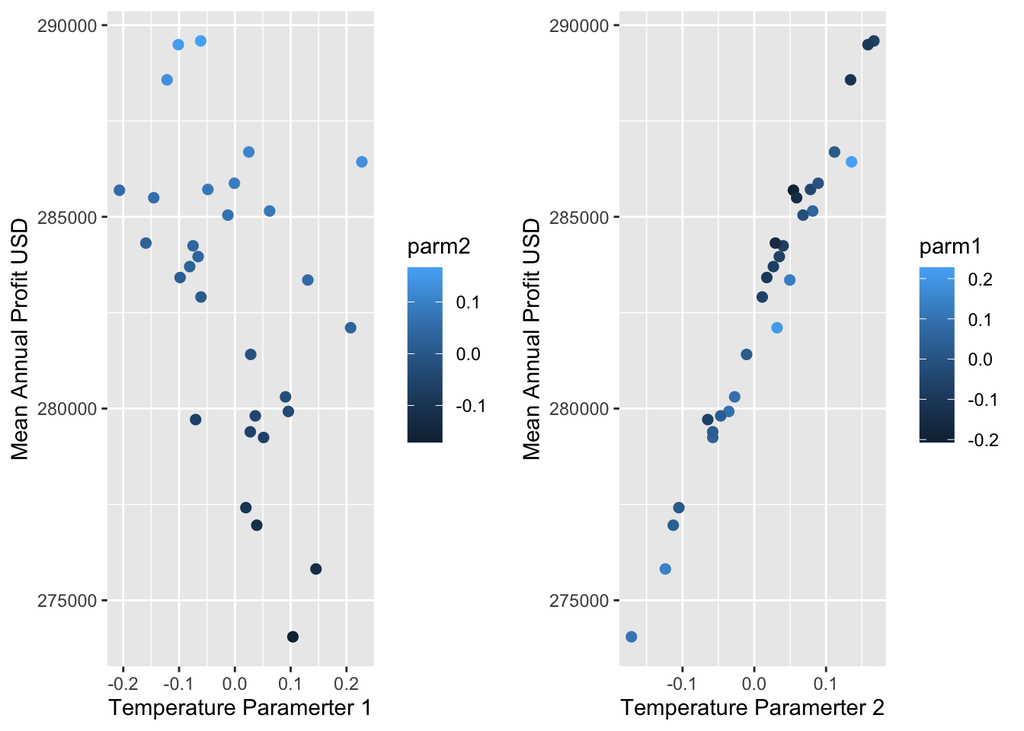

```r
# create plots
p1 = ggplot(mean_profit_w_params,
            aes(parm1, mean_profit, col=parm2))+geom_point(cex=2)+
  labs(y="Mean Annual Profit USD", x="Temperature Paramerter 1")

p2 = ggplot(mean_profit_w_params,
            aes(parm2, mean_profit, col=parm1))+geom_point(cex=2)+
  labs(y="Mean Annual Profit USD", x="Temperature Paramerter 2")

ggarrange(p1,p2)
```

In your same groups -

- Develop a profit model for your almond yield (you can make this up - think about what the parameters would be)

  ```
  * you might assume a baseline profit and then adjust according to the anomaly
  ```

  - there are many ways to combine the almond yield and profit functions; you can have the profit function “call”/use the almond yield function; or create a wrapper function that calls them in sequence (first the almond yield and then the profit function)
- Do a simple informal sensitivity analysis of almond yield profit using at least 2 parameters
- Create a single graph of the results - you can decide what is the most meaningful graph

Submit as a group: a knitted Rmarkdown document that includes your graph, and your R files for almond yield and profit model